# CA4: Machine Learning (ML)

## Amir Ali Vahidi 810199511

#### Import needed libraries for further uses

```python
from colorama import Fore ,Back ,Style
import seaborn as sns
import pandas as pd
```

```python
data = pd.read_csv("diabetes.csv")
```

### Part1: Data Set Review

##### Q1:

```python
data.info()
```

```
<class 'pandas.core.frame.DataFrame'>
RangeIndex: 768 entries, 0 to 767
Data columns (total 9 columns):
 #   Column                    Non-Null Count  Dtype
---  ------                    --------------  -----
 0   Pregnancies               635 non-null    float64
 1   Glucose                   654 non-null    float64
 2   BloodPressure             680 non-null    float64
 3   SkinThickness             624 non-null    float64
 4   Insulin                   680 non-null    float64
 5   BMI                       684 non-null    float64
 6   DiabetesPedigreeFunction  590 non-null    float64
 7   Age                       655 non-null    float64
 8   Outcome                   768 non-null    int64
dtypes: float64(8), int64(1)
memory usage: 54.1 KB
```

```python
data.describe()
```

|  | Pregnancies | Glucose | BloodPressure | SkinThickness | Insulin | BMI | DiabetesPedigreeFunction | Age | Outcome |
| --- | --- | --- | --- | --- | --- | --- | --- | --- | --- |
| count | 635.000000 | 654.000000 | 680.000000 | 624.000000 | 680.000000 | 684.000000 | 590.000000 | 655.000000 | 768.000000 |
| mean | 3.700787 | 113.422018 | 68.786765 | 20.386218 | 80.123529 | 32.083626 | 0.466676 | 33.157252 | 0.348958 |
| std | 3.518126 | 202.816831 | 19.724841 | 15.987049 | 115.681140 | 7.800741 | 0.322408 | 13.829831 | 0.476951 |
| min | -22.000000 | -5000.000000 | -2.000000 | 0.000000 | 0.000000 | 0.000000 | 0.078000 | -150.000000 | 0.000000 |
| 25% | 1.000000 | 99.000000 | 62.000000 | 0.000000 | 0.000000 | 27.375000 | 0.243250 | 24.000000 | 0.000000 |
| 50% | 3.000000 | 117.000000 | 72.000000 | 23.000000 | 34.000000 | 32.300000 | 0.368000 | 29.000000 | 0.000000 |
| 75% | 6.000000 | 140.750000 | 80.000000 | 32.000000 | 129.250000 | 36.600000 | 0.611500 | 41.000000 | 1.000000 |
| max | 17.000000 | 199.000000 | 122.000000 | 99.000000 | 846.000000 | 67.100000 | 2.329000 | 81.000000 | 1.000000 |

##### Q2:

number and ratio of lost datas:

```python
#def get_feauters(dataset):return [columns for columns in dataset]
#features = get_feauters(data)
data_count=len(data)
for feature in data:
    lost_data=data[feature].isna().sum()
    lost_ratio=lost_data*100/data_count
    print(Back.RED+feature, ":",Back.RESET)
    print("lost data count:", lost_data)
    print("lost data ratio:", lost_ratio,"%")
    print()
```

```
Pregnancies :
lost data count: 133
lost data ratio: 17.317708333333332 %

Glucose :
lost data count: 114
lost data ratio: 14.84375 %

BloodPressure :
lost data count: 88
lost data ratio: 11.458333333333334 %

SkinThickness :
lost data count: 144
lost data ratio: 18.75 %

Insulin :
lost data count: 88
lost data ratio: 11.458333333333334 %

BMI :
lost data count: 84
lost data ratio: 10.9375 %

DiabetesPedigreeFunction :
lost data count: 178
lost data ratio: 23.177083333333332 %

Age :
lost data count: 113
lost data ratio: 14.713541666666666 %

Outcome :
lost data count: 0
lost data ratio: 0.0 %
```

##### Q3: Correlation Plot

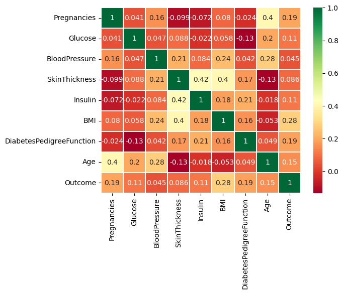

```python
corr=data.corr()
#corr.style.background_gradient(cmap='RdYlGn')
sns.heatmap(data.corr(), cmap ='RdYlGn', linewidths = 0.30, annot = True) # another implementation
```

As we can see in the heatmap, BMI(0.28) & DiabetesPedigreeFunction(0.19) & Pregnancies(0.19) are more related to the outcome.

##### Q4:

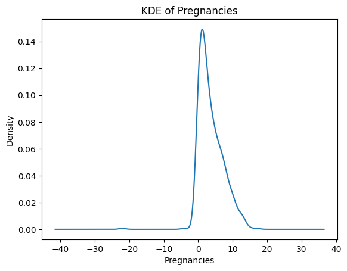

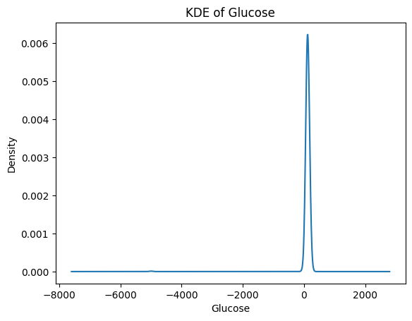

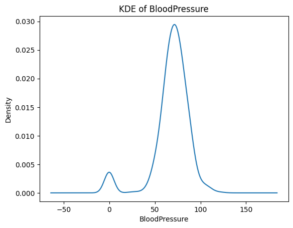

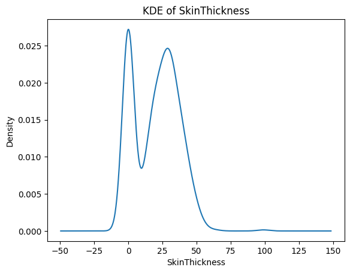

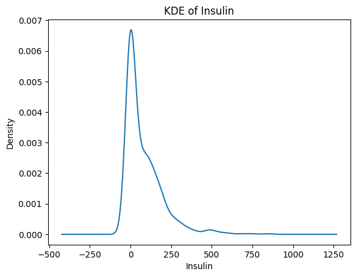

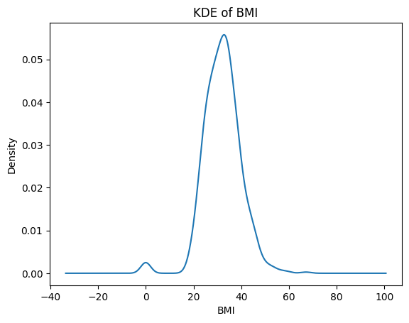

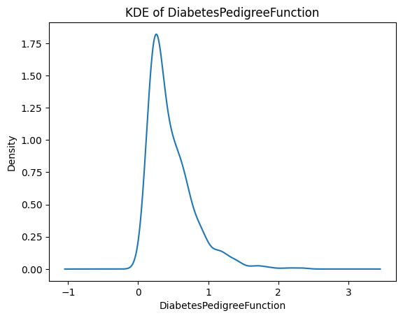

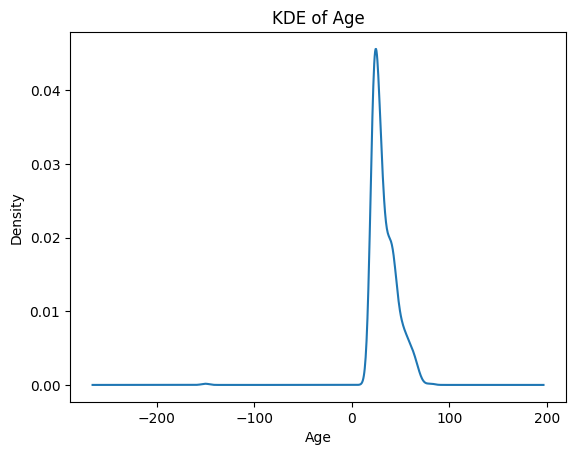

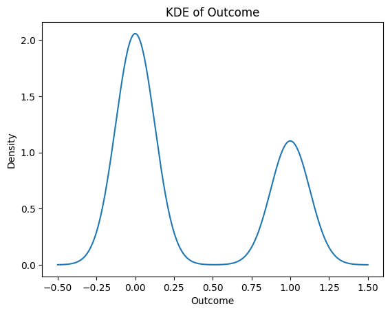

```python
import matplotlib.pyplot as plt
for feature in data:
    plt.figure()
    plt.title('KDE of {}'.format(feature))
    data[feature].plot.kde()
    plt.ylabel('Density')
    plt.xlabel(feature)
    plt.show()
# print(data_unique)
#print(list(data_age))
#data_age.style.background_gradient(cmap='RdYlGn')
```

##### Q5:

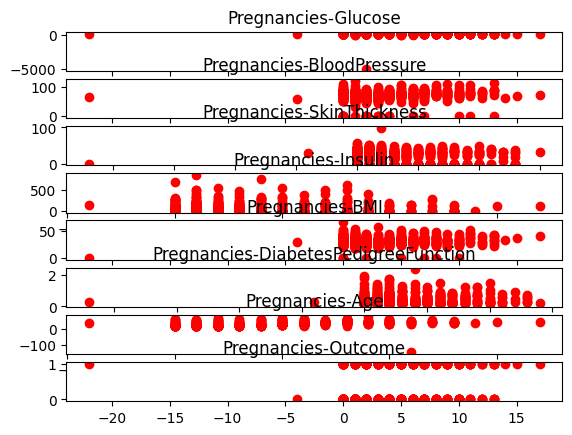

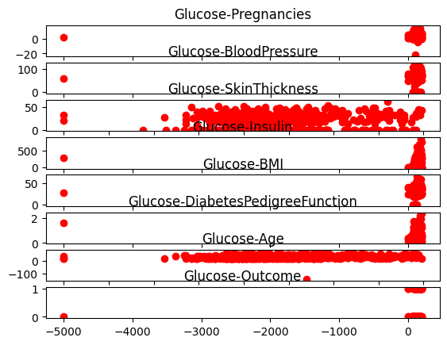

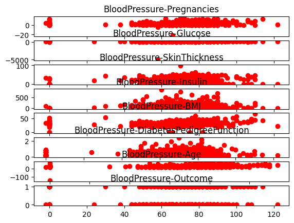

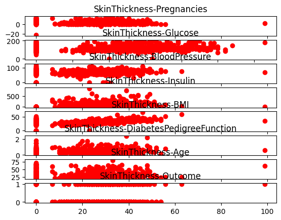

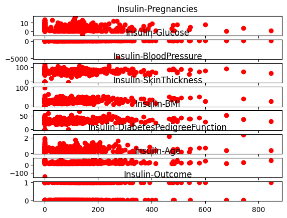

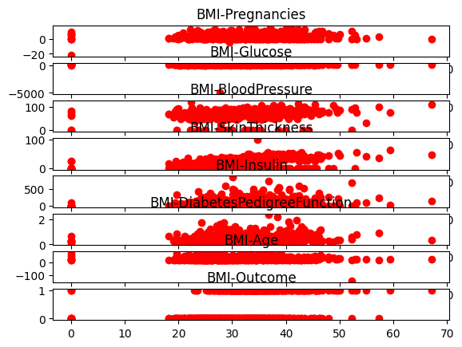

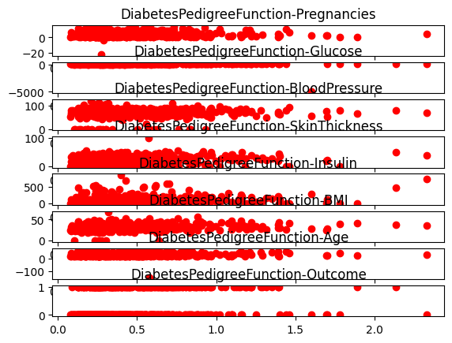

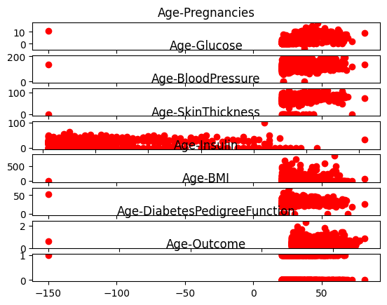

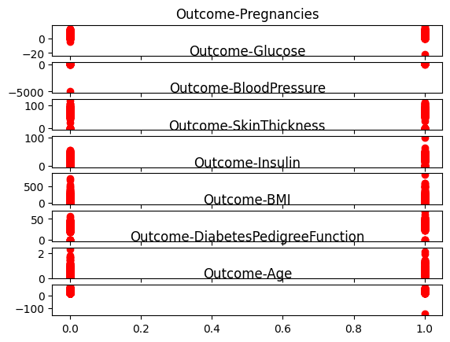

```python
for feature in data:
    i=0
    figure, axis = plt.subplots(8)
    for feature2 in data:
        if feature != feature2:
            #plt.scatter(data[feature] , data[feature2], c='red')
            axis[i].scatter(data[feature] , data[feature2], c='red')
            axis[i].set_title(feature+"-"+feature2)
            i+=1
            # plt.xlabel(feature)
            # plt.ylabel(feature2)

    plt.show()
```

### Part 2: Pre-Process

##### Q1: **Methods to Solve Missing Values Problem in Dataset**

A. Deletion of missing values

B. Impute by Average(mean,mode,linear regression)

C. Impute by Predictive Model(Decision Tree, KNN, Random Forest, etc.)

Imputation of missing values is a tricky subject and unless the missing data is not observed completely at random, imputing such missing values by a Predictive Model is highly desirable since it can lead to better insights and overall increase in performance of the predictive models.

##### Q2: **Missing Values in diabetes Dataset & Solving them**

Most missing value rates among features belongs to these features:

- DiabetesPedigreeFunction with 23.177 %
- SkinThickness with 18.75 %
- Pregnancies with 17.317 %

```python
import numpy as np
zero_not_accepted = ['Glucose','BloodPressure','SkinThickness','BMI','Insulin']
for column in zero_not_accepted:
    data[column] = data[column].replace(0,np.NaN)
    mean = int(data[column].mean(skipna=True))
    data[column] = data[column].replace(np.NaN,mean)

data['DiabetesPedigreeFunction'] = data['DiabetesPedigreeFunction'].fillna(data['DiabetesPedigreeFunction'].mean())
data['Pregnancies'] = data['Pregnancies'].fillna(data['Pregnancies'].mean())
data['Age'] = data['Age'].fillna(data['Age'].mean())
```

##### Q3: **Purpose of normalization in numerical features**

Normalization ensures that the features we use in computations are not affected by trivial variations like height, width, scaling factors, orientations etc. Bringing the data values to a specific range makes them independent of these factors e.g. normalizing a series of lengths to the range [0, 1] means they are nor affected by scaling factors as absolute values are now converted to ratios.

In this project, we better use the normalization for better performance.

##### Q4: **What pre-processes works on categorical features**

There are two types of categorical features.  
*I.* Categorial  
*II.* Ordinal : special case of categorical feature but with values sorted in some meaningful order.

We can use the following encodings:

- **Label Encoding** : It basically replaces the unique values of categorical features with numbers.
- **Frequency Encoding** : It maps unique values to their frequencies.
- **One-Hot Encoding** : It creates new columns for each unique value of a categorical feature and assigns 1 or 0 to each row based on the value of the feature.\

Label encoding and Frequency encoding are often used for tree-based methods while One-Hot encoding is often used for non-tree-based-methods.

##### Q5: **Is it possible to remove some columns**

Yes, we can remove some columns. But, we should be careful about the columns that we remove.  
There are some cases that we can remove a column from the dataset:

- We can remove the columns that have a high correlation with other columns.
- We can remove the columns that have a low correlation with the target column.
- We can remove the columns that have a high number of missing values or unique values.

##### Q6: **How to divide datas into train dataset and test dataset**

The most common split ratio is 80:20. But as long as underfitting and overfitting are not a problem, the split ratio can be changed.

##### Q7: **Validation**

In validation we use set of examples used to tune the parameters of a classifier.  
Validation dataset is the sample of data used to provide an unbiased evaluation of a model fit on the training dataset while tuning model hyperparameters. The evaluation becomes more biased as skill on the validation dataset is incorporated into the model configuration.

### Part3: Training, Evaluation & Regulation

##### Data Partitioning

```python
from sklearn.model_selection import train_test_split
X= data.values[:,0:8]
Y = data.values[:,8]
X_train , X_test , y_train , y_test = train_test_split(X,Y,test_size=0.2,random_state=0)
```

##### Decision Tree Learning

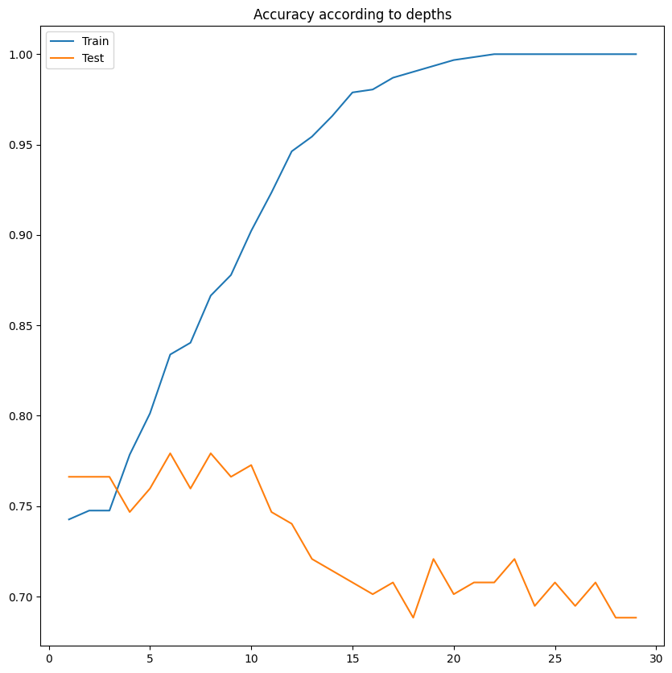

```python
from sklearn.tree import DecisionTreeClassifier
from sklearn.metrics import accuracy_score
depths = range(1, 30)

test = []
train = []

for i in depths:
    tree = DecisionTreeClassifier(max_depth=i)
    tree.fit(X_train,y_train)

    train_pred= tree.predict(X_train)
    train.append(accuracy_score(y_train, train_pred))

    test_pred = tree.predict(X_test)
    test.append(accuracy_score(y_test, test_pred))

plt.figure(figsize=(10, 10))
plt.plot(depths, train, label='Train')
plt.plot(depths, test, label='Test')
plt.legend()
plt.title('Accuracy according to depths')
plt.show()
```

We choose depth = 5 to avoid underfitting and overfitting.

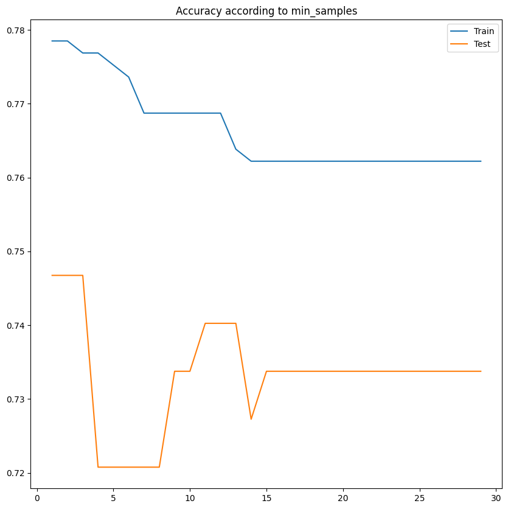

```python
leaves = range(1, 30)

test = []
train = []

for i in leaves:
    tree = DecisionTreeClassifier(max_depth=4, min_samples_leaf=i)
    tree.fit(X_train,y_train)

    train_pred= tree.predict(X_train)
    train.append(accuracy_score(y_train, train_pred))

    test_pred = tree.predict(X_test)
    test.append(accuracy_score(y_test, test_pred))

plt.figure(figsize=(10, 10))
plt.plot(depths, train, label='Train')
plt.plot(depths, test, label='Test')
plt.legend()
plt.title('Accuracy according to min_samples')
plt.show()
```

I choose min_leaf = 15 to avoid underfitting and overfitting. So the final model will be:

```python
tree = DecisionTreeClassifier(max_depth=5, min_samples_leaf=15)
clf = tree.fit(X_train,y_train)
y_pred=clf.predict(X_test)
print("Test data prediction:")
print(y_pred)
```

```
Test data prediction:
[1. 0. 0. 1. 0. 0. 1. 1. 0. 0. 1. 1. 0. 0. 1. 0. 1. 0. 0. 0. 0. 0. 0. 0.
 0. 0. 0. 1. 0. 0. 0. 0. 0. 0. 0. 1. 0. 0. 0. 1. 1. 0. 0. 1. 1. 0. 0. 0.
 0. 0. 0. 0. 1. 0. 0. 0. 0. 0. 0. 0. 1. 1. 0. 0. 1. 1. 1. 0. 0. 0. 0. 0.
 0. 1. 1. 0. 0. 1. 0. 0. 0. 0. 0. 0. 0. 0. 0. 0. 1. 0. 0. 0. 0. 0. 1. 0.
 0. 0. 1. 0. 0. 0. 0. 0. 0. 0. 0. 0. 0. 1. 0. 0. 0. 0. 1. 0. 0. 1. 0. 1.
 0. 0. 0. 0. 0. 0. 0. 1. 0. 1. 0. 0. 0. 1. 0. 0. 0. 0. 0. 0. 0. 1. 0. 0.
 0. 0. 0. 0. 0. 0. 0. 0. 0. 0.]
```

```python
# from sklearn import tree

# clf = tree.DecisionTreeClassifier(criterion="entropy", max_depth=3, min_samples_leaf=5)
# clf = clf.fit(X_train, y_train)
# y_pred=clf.predict(X_test)
# print("Test data prediction:")
# print(y_pred)
# # print("Accuracy:",clf.score(y_test, y_pred)*100,"%")
```

confusion matrix for DTL

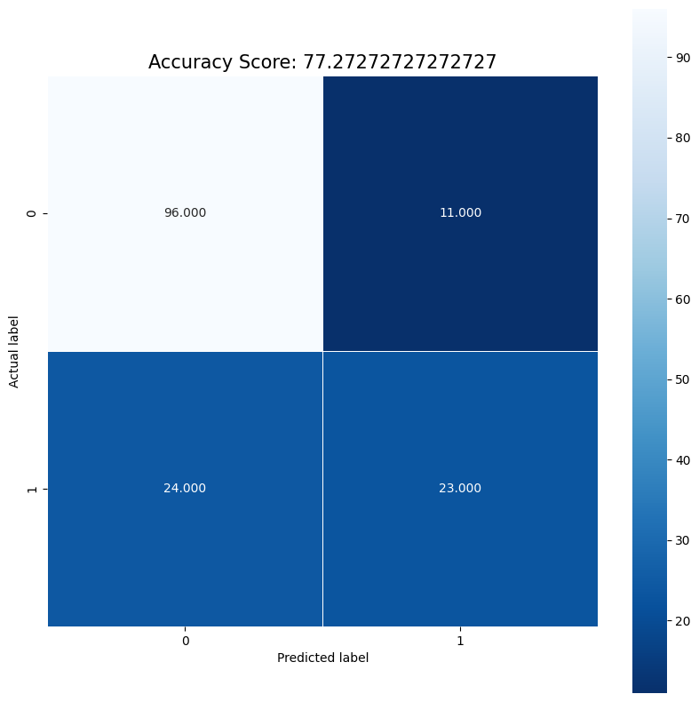

```python
from sklearn.metrics import confusion_matrix
from sklearn.metrics import accuracy_score
conf_matrix=confusion_matrix(y_test , y_pred)
plt.figure(figsize=(10,10))
sns.heatmap(conf_matrix, annot=True, fmt=".3f", linewidths=.5, square = True, cmap = 'Blues_r')
plt.ylabel('Actual label')
plt.xlabel('Predicted label')
all_sample_title = 'Accuracy Score: {0}'.format(accuracy_score(y_test, y_pred)*100,"%")
plt.title(all_sample_title, size = 15)
```

```python
from sklearn.metrics import accuracy_score
print(Back.BLUE+"Accuracy on test is:"+Back.RESET, accuracy_score(y_test, y_pred)*100,"%")
```

```
Accuracy on test is: 77.27272727272727 %
```

```python
# tree.plot_tree(clf)
from sklearn import tree
import os
import graphviz
os.environ["PATH"] += os.pathsep + 'C:\Program Files\Graphviz\bin'
dot_data = tree.export_graphviz(clf, out_file=None,
                     feature_names=[f for f in data][:8],
                     filled=True, rounded=True,
                     special_characters=True)
graph = graphviz.Source(dot_data)
graph.render("DECISION TREE") # save the graph as pdf file
graph
```

[output not shown]

##### K-Nearest-Neighbors

scaling

```python
from sklearn.preprocessing import StandardScaler
from sklearn.neighbors import KNeighborsClassifier
# standard scale sets all data values between -1 and 1
scaled_X_train = StandardScaler().fit_transform(X_train)
scaled_X_test = StandardScaler().fit_transform(X_test)
```

code

```python
# use for choosing k
import math
math.sqrt(len(y_test))
```

```
12.409673645990857
```

```python
# p=1 for manhattan_distance, p=2 for euclidean_distance
# n_neighbors must be odd numbers so that it can decide the class of the test data
clf = KNeighborsClassifier(n_neighbors=15 , p=2 , metric='euclidean')
clf = clf.fit(X_train, y_train)
y_pred = clf.predict(X_test)
print(y_pred)
```

```
[1. 0. 0. 1. 0. 0. 1. 1. 0. 0. 1. 0. 0. 0. 1. 0. 1. 0. 0. 0. 1. 0. 0. 0.
 0. 0. 0. 1. 0. 0. 0. 0. 0. 1. 0. 1. 1. 0. 0. 0. 0. 0. 0. 1. 1. 0. 0. 0.
 0. 1. 1. 0. 0. 0. 0. 0. 0. 0. 0. 1. 1. 1. 0. 0. 1. 1. 1. 1. 1. 0. 0. 0.
 0. 0. 1. 0. 0. 1. 0. 0. 1. 0. 0. 0. 0. 0. 0. 0. 1. 0. 1. 0. 0. 0. 0. 0.
 0. 0. 0. 1. 0. 0. 0. 0. 1. 0. 0. 0. 0. 1. 0. 1. 1. 0. 1. 0. 0. 1. 0. 1.
 0. 0. 0. 0. 0. 0. 0. 0. 0. 1. 0. 0. 0. 1. 0. 0. 0. 0. 0. 0. 0. 1. 0. 0.
 1. 0. 0. 0. 0. 0. 0. 1. 0. 0.]
```

Evaluate Model

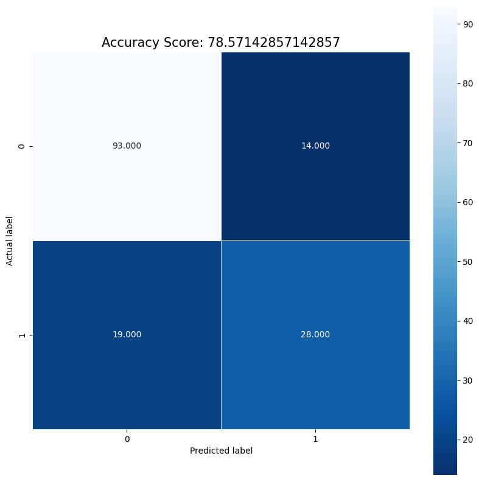

```python
conf_matrix=confusion_matrix(y_test , y_pred)
plt.figure(figsize=(10,10))
sns.heatmap(conf_matrix, annot=True, fmt=".3f", linewidths=.5, square = True, cmap = 'Blues_r')
plt.ylabel('Actual label')
plt.xlabel('Predicted label')
all_sample_title = 'Accuracy Score: {0}'.format(accuracy_score(y_test, y_pred)*100,"%")
plt.title(all_sample_title, size = 15)
```

```python
print(Back.BLUE+"Accuracy on test is:"+Back.RESET, accuracy_score(y_test, y_pred)*100,"%")
```

```
Accuracy on test is: 78.57142857142857 %
```

##### Logistic Regression

scaling

```python
from sklearn.preprocessing import StandardScaler
from sklearn.linear_model import LogisticRegression
# standard scale sets all data values between -1 and 1
scaled_X_train = StandardScaler().fit_transform(X_train)
scaled_X_test = StandardScaler().fit_transform(X_test)
```

```python
clf = LogisticRegression()
clf = clf.fit(X_train, y_train)
y_pred = clf.predict(X_test)
print(y_pred)
# y_pred = clf.predict(X_test)
# print(y_pred)
```

```
[1. 0. 0. 1. 0. 0. 1. 1. 0. 0. 1. 1. 0. 0. 0. 0. 1. 0. 0. 0. 1. 0. 0. 0.
 0. 0. 0. 1. 0. 0. 0. 0. 0. 0. 0. 1. 0. 0. 0. 1. 0. 0. 0. 1. 1. 0. 0. 0.
 0. 0. 0. 0. 1. 1. 0. 0. 0. 1. 0. 0. 1. 1. 0. 1. 1. 1. 1. 0. 0. 0. 0. 0.
 0. 1. 1. 0. 0. 1. 0. 0. 0. 1. 0. 0. 0. 0. 0. 0. 1. 0. 0. 0. 0. 0. 1. 0.
 0. 0. 1. 0. 0. 0. 0. 0. 1. 0. 0. 0. 0. 1. 0. 0. 1. 0. 1. 0. 0. 1. 0. 1.
 0. 0. 0. 0. 0. 0. 0. 0. 0. 1. 0. 0. 0. 1. 0. 0. 0. 0. 0. 0. 0. 1. 0. 0.
 0. 0. 0. 0. 0. 0. 0. 1. 0. 0.]
```

[output not shown]

confusion matrix heat map

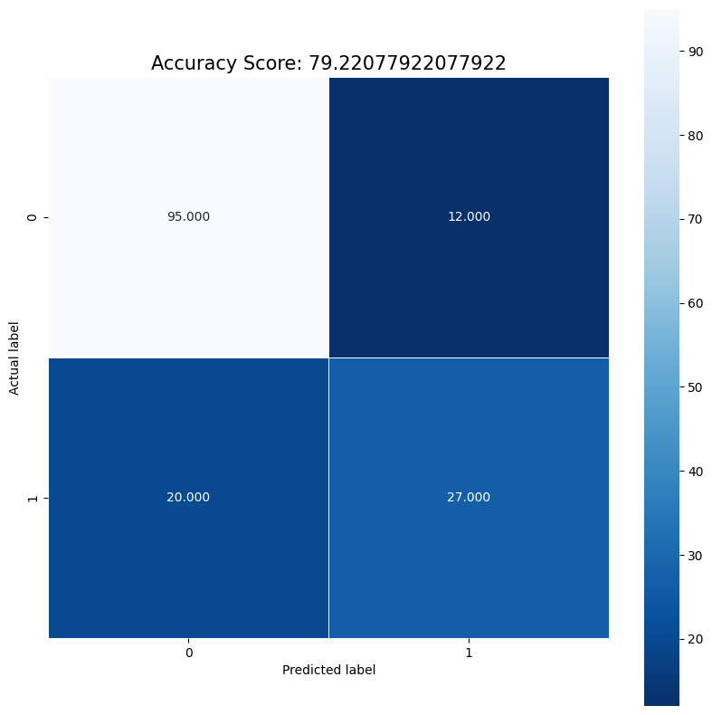

```python
conf_matrix=confusion_matrix(y_test , y_pred)
plt.figure(figsize=(10,10))
sns.heatmap(conf_matrix, annot=True, fmt=".3f", linewidths=.5, square = True, cmap = 'Blues_r')
plt.ylabel('Actual label')
plt.xlabel('Predicted label')
all_sample_title = 'Accuracy Score: {0}'.format(accuracy_score(y_test, y_pred)*100,"%")
plt.title(all_sample_title, size = 15)
```

```python
print(Back.BLUE+"Accuracy on test is:"+Back.RESET, accuracy_score(y_test, y_pred)*100,"%")
```

```
Accuracy on test is: 79.22077922077922 %
```

##### Q3: **Overfittng & Underfitting**

**Overfitting** : When a model is too complex for the given data, it will learn the noise in the data and will not be able to generalize well on the test data.  
**Underfitting** : When a model is too simple for the given data, it will not be able to learn the underlying patterns in the data and will not be able to generalize well on the test data.

### Part 4: Ensemble Learning

```python
from sklearn.ensemble import RandomForestClassifier
```

##### Q1: **Random Forest Hyperparameters**

- **n_estimators** : The number of trees in the forest.
- **max_features** : The number of features to consider when looking for the best split.
- **max_depth** : The maximum depth of the tree.
- **min_samples_split** : The minimum number of samples required to split an internal node.
- **min_samples_leaf** : The minimum number of samples required to be at a leaf node.
- **bootstrap** : Whether bootstrap samples are used when building trees.

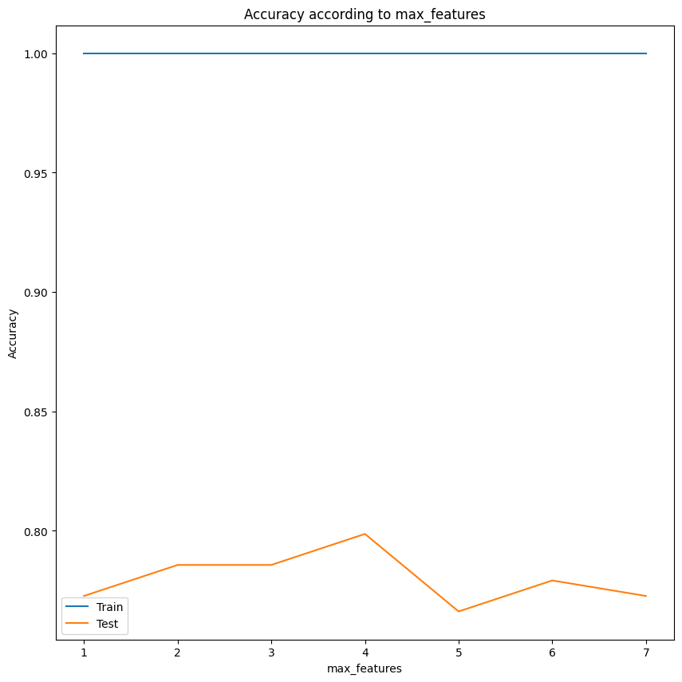

```python
# changing max_feature parameter
max_features = range(1, 8)

test = []
train = []

for i in max_features:
    forest = RandomForestClassifier(max_features=i)
    forest.fit(X_train,y_train)

    train_pred= forest.predict(X_train)
    train.append(accuracy_score(y_train, train_pred))

    test_pred = forest.predict(X_test)
    test.append(accuracy_score(y_test, test_pred))

plt.figure(figsize=(10, 10))
plt.plot(max_features, train, label='Train')
plt.plot(max_features, test, label='Test')
plt.xlabel('max_features')
plt.ylabel('Accuracy')
plt.legend()
plt.title('Accuracy according to max_features')
plt.show()
```

As we can see here, beacause max_features result will be diffrent every time based on selected features, we will **NOT** use this hyperparameter.

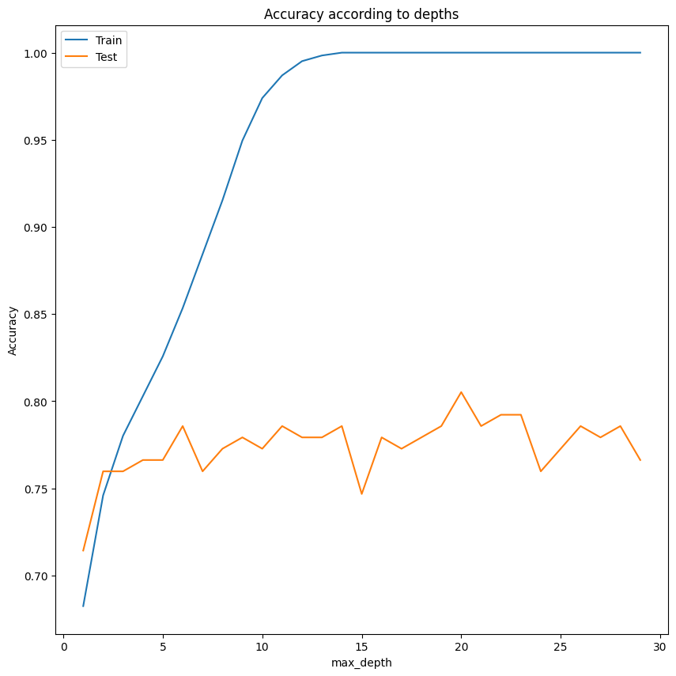

```python
# changing max_depth parameter
max_depths = range(1, 30)

test = []
train = []

for i in max_depths:
    forest = RandomForestClassifier(max_depth=i)
    forest.fit(X_train,y_train)

    train_pred= forest.predict(X_train)
    train.append(accuracy_score(y_train, train_pred))

    test_pred = forest.predict(X_test)
    test.append(accuracy_score(y_test, test_pred))

plt.figure(figsize=(10, 10))
plt.plot(max_depths, train, label='Train')
plt.plot(max_depths, test, label='Test')
plt.xlabel('max_depth')
plt.ylabel('Accuracy')
plt.legend()
plt.title('Accuracy according to depths')
plt.show()
```

We choose max_depth = 20 to avoid underfitting and overfitting.

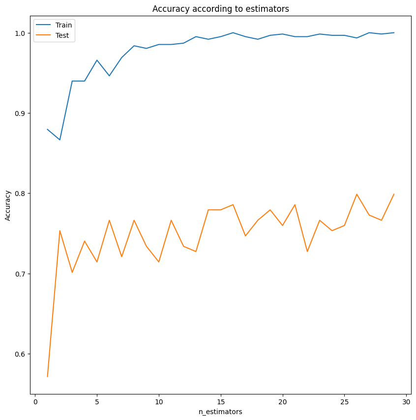

```python
# changing n_estimators parameter
estimators = range(1, 30)

test = []
train = []

for i in estimators:
    forest = RandomForestClassifier(max_depth=20, n_estimators=i)
    forest.fit(X_train,y_train)

    train_pred= forest.predict(X_train)
    train.append(accuracy_score(y_train, train_pred))

    test_pred = forest.predict(X_test)
    test.append(accuracy_score(y_test, test_pred))

plt.figure(figsize=(10, 10))
plt.plot(depths, train, label='Train')
plt.plot(depths, test, label='Test')
plt.xlabel('n_estimators')
plt.ylabel('Accuracy')
plt.legend()
plt.title('Accuracy according to estimators')
plt.show()
```

We choose n_estimators = 27 to avoid underfitting and overfitting.

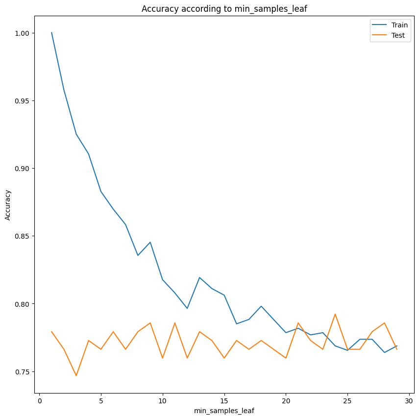

```python
# changing min_samples_leaf parameter
min_samples_leafs = range(1, 30)

test = []
train = []

for i in min_samples_leafs:
    forest = RandomForestClassifier(max_depth=20, n_estimators=27,min_samples_leaf=i)
    forest.fit(X_train,y_train)

    train_pred= forest.predict(X_train)
    train.append(accuracy_score(y_train, train_pred))

    test_pred = forest.predict(X_test)
    test.append(accuracy_score(y_test, test_pred))

plt.figure(figsize=(10, 10))
plt.plot(min_samples_leafs, train, label='Train')
plt.plot(min_samples_leafs, test, label='Test')
plt.xlabel('min_samples_leaf')
plt.ylabel('Accuracy')
plt.legend()
plt.title('Accuracy according to min_samples_leaf')
plt.show()
```

We choose min_samples_leafs = 11 to avoid underfitting and overfitting.

The final model will be:

```python
forest = RandomForestClassifier(max_depth=20, n_estimators=27,min_samples_leaf=11)
clc=forest.fit(X_train,y_train)
y_pred = forest.predict(X_test)
print(y_pred)
```

```
[1. 0. 0. 1. 0. 0. 1. 1. 0. 0. 1. 1. 0. 0. 0. 0. 1. 0. 1. 0. 1. 0. 0. 0.
 0. 0. 0. 1. 0. 0. 0. 0. 0. 0. 0. 1. 0. 0. 0. 1. 0. 0. 0. 1. 1. 0. 0. 0.
 0. 0. 0. 0. 1. 1. 0. 0. 0. 0. 0. 0. 1. 1. 0. 1. 1. 1. 1. 0. 0. 0. 0. 0.
 0. 1. 1. 0. 0. 1. 0. 0. 0. 1. 0. 0. 0. 0. 0. 0. 1. 0. 0. 0. 0. 0. 1. 0.
 0. 0. 1. 1. 0. 0. 0. 0. 1. 0. 0. 1. 0. 1. 0. 1. 1. 0. 1. 0. 0. 0. 0. 1.
 0. 0. 0. 0. 0. 0. 0. 1. 0. 1. 0. 0. 0. 1. 0. 0. 0. 0. 0. 0. 0. 1. 0. 0.
 0. 0. 0. 0. 0. 0. 0. 1. 0. 0.]
```

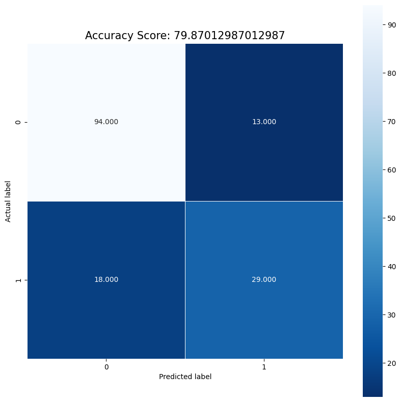

```python
conf_matrix=confusion_matrix(y_test , y_pred)
plt.figure(figsize=(10,10))
sns.heatmap(conf_matrix, annot=True, fmt=".3f", linewidths=.5, square = True, cmap = 'Blues_r')
plt.ylabel('Actual label')
plt.xlabel('Predicted label')
all_sample_title = 'Accuracy Score: {0}'.format(accuracy_score(y_test, y_pred)*100,"%")
plt.title(all_sample_title, size = 15)
```

##### Q2: **Compare Random Forest to Decision Tree**

**`Bias`** : Bias is the difference between the expected prediction of our model and the correct value which we are trying to predict.  
**`Variance`** : Variance is the amount that the estimate of the target function will change if different training data was used.

**Different Combinations of Bias-Variance** :

- Low-Bias, Low-Variance:\

The combination of low bias and low variance shows an ideal machine learning model. However, it is not possible practically.

- High-Bias, Low-Variance:\

The combination of high bias and low variance shows an underfitting model.

- Low-Bias, High-Variance:\

The combination of low bias and high variance shows an overfitting model.

- High-Bias, High-Variance:\

The combination of high bias and high variance shows a very complex model.

Random Forest is a combination of Decision Trees. So, we can compare them based on their bias and variance.

- **Bias**: Random Forest has a higher bias than Decision Tree.
- **Variance**: Random Forest has a lower variance than Decision Tree.